# How To Drink Your Beer

Wang YueDuo, sdu202000700268

2022-03-18

## Question 1: Write down the Null and the alternative hypotheses.

## My answer:

The research question is : Whether the time taken to drink a beer was influenced by the shape of the glass in which it was served?

The null hypotheses is: The time taken to drink a beer is not influenced by the shape of the glass in which it was served, and the relationship between time taken to drink a bear and shape of glass are independent. The alternative hypotheses is: The time taken to drink a beer is influenced by the shape of the glass in which it was served, and the relationship between time taken to drink a bear and shape of glass are dependent.

## Question 2: Describe the data, using full sentences:

## My answer:

First of all, read the file:

```r
beer <- read.csv("beer.csv",stringsAsFactors = T)
print(beer)
```

```
##    glassShape drinkingTime
## 1    straight        11.63
## 2    straight        10.37
## 3    straight        17.89
## 4    straight         6.96
## 5    straight        20.40
## 6    straight        20.64
## 7    straight         9.26
## 8    straight        18.11
## 9    straight        10.33
## 10   straight        23.54
## 11     curved         7.46
## 12     curved         9.28
## 13     curved         8.90
## 14     curved         6.73
## 15     curved         8.25
## 16     curved         6.16
## 17     curved        13.09
## 18     curved         2.10
## 19     curved         6.37
```

#### Is the data continuous or discrete?

The data “glass Shape” is discrete. The data “drinking Time” is continuous.

#### Provide basic characteristics of the data: Mean, minimum, and maximum for continuous; number and names of groups for discrete.

```r
# calculate mean, minimum and maximum for continuous:
mean(beer$drinkingTime)
```

```
## [1] 11.44579
```

```r
min(beer$drinkingTime)
```

```
## [1] 2.1
```

```r
max(beer$drinkingTime)
```

```
## [1] 23.54
```

```r
# Calculate number of groups for discrete
nlevels(beer$glassShape)
```

```
## [1] 2
```

Thus: Basic characteristics for continuous data: mean=11.44579, minimum=2.1, maximum=23.54. Basic characteristics for discrete data: there are 2 types of discrete data: the glass shape is “Straight” or “Curved”.

#### How many observations were conducted?

```r
nrow(beer)
```

```
## [1] 19
```

Therefor,19 observations were conducted.

#### What was the sample size (be careful with your answer).

```r
# First, we should separate out the discrete data:
str <- beer[beer$glassShape == 'straight', 'drinkingTime']
cur <- beer[beer$glassShape == 'curved', 'drinkingTime']
# Print out discrete data:
str
```

```
##  [1] 11.63 10.37 17.89  6.96 20.40 20.64  9.26 18.11 10.33 23.54
```

```r
cur
```

```
## [1]  7.46  9.28  8.90  6.73  8.25  6.16 13.09  2.10  6.37
```

```r
# Next, we should calculate the sample size of straight and curved glass separately, and add them up in order to get the sample size.
# Considered that the size of sample is a vector, we cannot use nrow(). Thus, we use length() to calculate.
length(str)
```

```
## [1] 10
```

```r
length(cur)
```

```
## [1] 9
```

```r
# Add them up
length(str) + length(cur)
```

```
## [1] 19
```

Thus, the sample size is 19. (10 straight + 9 curved)

## Question3: Make a box plot presenting the data. Use colors and label the axes.

### My answer:

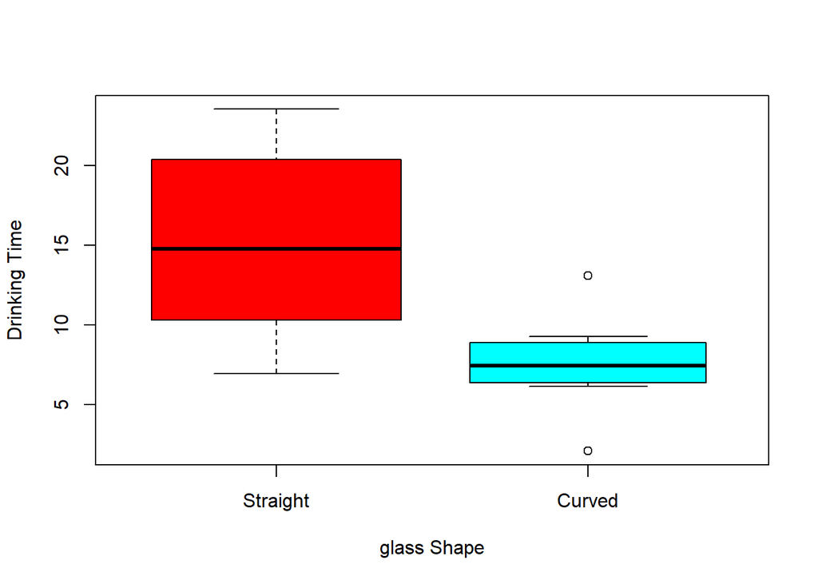

```r
# We have separate out the discrete data: the sample of straight and curved glass shape in question 2, and now we just need to make a box plot:
boxplot(str, cur,
        col= rainbow(2) ,
        names = c('Straight','Curved'),
        xlab = 'glass Shape',
        ylab = 'Drinking Time',
        varwidth = T)
```

This box plot shows that the mean of drinking time by using straight shape glass is about 15, while the mean of drinking time by using curved shape glass is about 8. Exclude the outliers in curved shape glass group, we can clearly obverse that the mean of drinking time by using straight shape glass is higher than the mean of drinking time by using curved shape glass. Which means that we have a large possibility to reject null hypotheses.

## Question 4:Write 2 - 3 sentences of explanations what statistical test would be appropriate for this problem and why.

### My answer:

I will consider Student-test (which is also called T-test). Because both of the size of straight and curved shape glass sample are less than 30, which means that they are small size sample. In this situation, commonly used normal distribution is approximately agree with T-test. For this reason, we use T-test. In t-test, value of the test statistics, df(free degree), p-value, 95% confidence interval and sample estimates would be tested, if p-value is less than 0.05, then it means we can reject null hypotheses.

## Question 5: Perform the test.

### My answer:

```r
# Because there are two groups, thus we use two sided test.
beer.t <- t.test(str, cur, alternative = "two.sided", var.equal = T)
beer.t
```

```
##
##  Two Sample t-test
##
## data:  str and cur
## t = 3.3977, df = 17, p-value = 0.003425
## alternative hypothesis: true difference in means is not equal to 0
## 95 percent confidence interval:
##   2.774455 11.864878
## sample estimates:
## mean of x mean of y
## 14.913000  7.593333
```

The output “alternative hypothesis: true difference in means is not equal to 0” means that, there exists difference between the drinking time of two group. Mean of x=14.913000 and mean of y=7.593333 means that, the mean of drinking time by using straight shape glass is 14.913000, while the mean of drinking time by using curved shape glass is 7.593333.

## Question 7: Write 5-10 sentences discussing the results, conclusions and answer to the research question. Your comments and thought on how this experiment could be improved and what were its weak points.

### My answer:

Our research question is : Whether the time taken to drink a beer was influenced by the shape of the glass in which it was served?

The null hypotheses is: The time taken to drink a beer is not influenced by the shape of the glass in which it was served, and the relationship between time taken to drink a bear and shape of glass are independent, while the alternative hypotheses is: The time taken to drink a beer is influenced by the shape of the glass in which it was served, and the relationship between time taken to drink a bear and shape of glass are dependent.

In this research, the size of the whole sample is 19, drinking time is continuous data, which have mean=11.44579, minimum=2.1, maximum=23.54, while there are 2 types of discrete data: the glass shape is “Straight” or “Curved”.

We made a box plot to present the relation between drinking time and shape of glass (straight or curved).

Excluded the outliers in curved shape glass group, we can clearly obverse that the mean of drinking time by using straight shape glass (about 15) is higher than the mean of drinking time by using curved shape glass (about 8), which means that we have a large possibility to reject null hypotheses.

Then we used T-test because the sample size is less than 30, and we got t = 3.3977, df = 17, p-value = 0.003425, which shown that p-value is much less than 0.05.

This means that we can reject null hypotheses.

#### Final Conclusion:

The drinking time of beer is influenced by the shape of the glass in which it was served, and the relationship between drinking time and shape of glass are dependent.

#### Open comments:

Different people may have different favor to different flavors of beer, and also different alcohol tolerance. Thus, it’s important to use same beer and same preference for beer during this test. In addition, people who have same alcohol tolerance are also should be found.

## End of Assignment: How To Drink Your Beer